# Results for Pacific Herring, Petrale Sole, and Pacific Cod

Andrew Edwards

Last rendered on 31 January, 2025

Set up:

```r
library(hdiAnalysis)
```

We generate plots for three further stocks here, as documented in the Supplementary Material. We keep this code short – for further investigations see the code in the respective species-specific code in `report/` or use further code in the other vignettes. Code to plot pdf version of the figures for each species is included here but hidden in the .html.

## Pacific Herring

We use results for the Strait of Georgia stock from Fisheries and Ocean Canada’s [Stock status update with application of management procedures for Pacific Herring (*Clupea pallasii*) in British Columbia: status in 2023 and forecast for 2024](https://publications.gc.ca/collections/collection_2024/mpo-dfo/fs70-7/Fs70-7-2024-001-eng.pdf). Following the assessment we calculate 90% (not 95%) credible intervals.

### Recruitment

Herring recruitment is given as numbers (in billions) of age-2 fish, rather than age-0 like for hake. To create ETIs and HDIs for estimates for each year:

```r
credibility_herring <- 0.90
res_all_years_herring_rec <- create_intervals(herring_recruitment_sog_mcmc,
                                              credibility = credibility_herring)
```

Full time series of recruitments using both types of intervals:

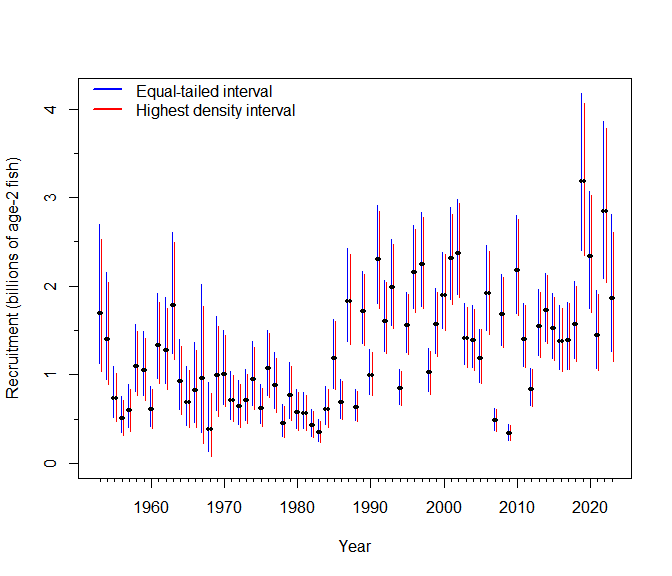

```r
plot(res_all_years_herring_rec,
     xlab = "Year",
     ylab = "Recruitment (billions of age-2 fish)",
     leg_loc = "topleft",
     y_tick_by = 0.5)
```

There is a slight lowering of the HDIs compared to the ETIs. The sum of the differences over all years between the width of the ETI and width of the HDI is (in billions of fish)

```r
res_all_years_herring_rec$intervals_all %>%
  dplyr::pull(width_diff) %>%
  sum()
```

```
#> [1] 1.580281
```

Thus a difference over a billion fish.

Across all five Pacific Herring major stocks the difference totals over 4.6 billion fish (using code in results/report-herring.Rmd). The area covered by these stocks is smaller than the area inhabited by Pacific Hake, and given also that herring recruitment is measured in terms of age-2 fish, this is a noteworthy reduction in the characterization of uncertainty of herring recruitment.

### Relative spawning biomass

For Pacific Herring, the limit reference point (below which the stock is declared to be in the critical zone) is defined as the spawning biomass being 30% of the unfished spawning biomass. For consistency with our hake analysis plot we show the relative biomass (spawning biomass over unfished spawning biomass, calculated for each MCMC sample) with a line at 0.3 representing this reference point.

```r
herring_relative_biomass_sog <- herring_biomass_sog_mcmc /
  herring_unfished_biomass_sog_mcmc
herring_relative_biomass_sog <- tibble::as_tibble(herring_relative_biomass_sog) %>%
  dplyr::select(-`2024`)
res_all_years_herring_relative_biomass <- create_intervals(herring_relative_biomass_sog,
                                          credibility = credibility_herring)
```

[output not shown]

(The Warnings are due to not being able to compute lower end of interval a, and we removed 2024 as that is a projection year assuming no fishing).

Plot the full time series like in our manuscript figure:

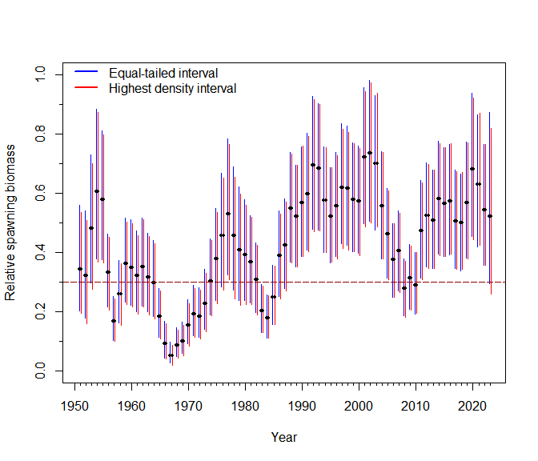

```r
plot(res_all_years_herring_relative_biomass,
     xlab = "Year",
     ylab = "Relative spawning biomass",
     ylim = c(0, 1),
     y_tick_by = 0.1,
     add_line = 0.3,
     add_line_col = "darkred",
     leg_loc = "topleft")
```

We can see visually that there are no years for which the ETIs and HDIs differ in whether they include the critical value of 0.3 (unlike for our hake example), although the final-year biomass does dip down somewhat further for the HDI than for the ETI.

Note that for Pacific Herring one of the management objectives is specifically to be above the limit reference point with at least 75% probability over three generations. So although perceptions of stock health might change when using HDIs versus ETIs, the different intervals would not change the results of using this specific clearly laid out management objective because it relies directly on probabilities.

## Petrale Sole

We use results from a stock assessment for the coastwide stock off British Columbia, Canada, of Petrale Sole (*Eopsetta jordani*), a flatfish. A two-sex statistical catch-at-age model developed with Stock Synthesis was used, with MCMC samples calculated using the ‘No U-Turn Sampling’ procedure. Natural mortality was fixed, and results for advice to management used an ensemble model that combined three different models that assumed different values of natural mortality (with 50% of total samples coming from one model and 25% from each of the other two).

Here we analyse relative spawning biomass, defined as the ratio of female spawning stock biomass to female spawning stock biomass at maximum sustainable yield ($B/B_{msy}$), using MCMC results provided by MacKenzie Mazur, from the Assessment of Petrale Sole in British Columbia in 2024 (in press) by Mackenzie Mazur, Kendra Holt, Nick Fisch, and Philina English. The ensemble model contains 27,995 values of $B/B_{msy}$ (which is 5 short of the expected total because $B_{msy}$ was not estimated for 5 samples), and 95% credible intervals were used. The limit reference point is when $B/B_{msy} = 0.4$.

### Relative spawning biomass

```r
credibility_petrale <- 0.95
res_all_years_petrale_relative_biomass <- create_intervals(petrale_relative_biomass_mcmc,
                                                           credibility = credibility_petrale)
```

Plotting the ETIs and HDIs:

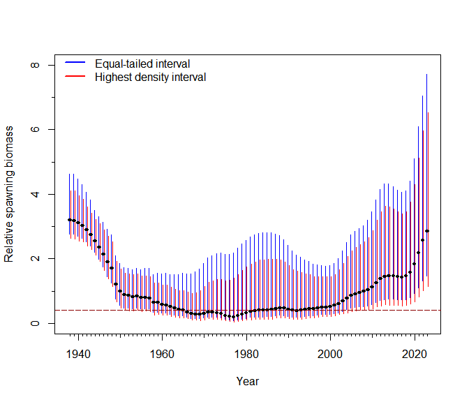

```r
plot(res_all_years_petrale_relative_biomass,
     xlab = "Year",
     ylab = "Relative spawning biomass",
     ylim = c(0, 8),
     leg_loc = "topleft",
     add_line = 0.4,
     add_line_col = "darkred")
```

At the low end of the intervals there are some years for which the ETI does not dip below the limit reference point at 0.4 (dashed dark red horizontal line) but the HDI does, namely

```r
dplyr::filter(res_all_years_petrale_relative_biomass$intervals_all,
              eti_lower > 0.4,
              hdi_lower < 0.4) %>%
  dplyr::select(quantity,
                eti_lower,
                hdi_lower)
```

```
#> # A tibble: 9 × 3
#>   quantity eti_lower hdi_lower
#>      <dbl>     <dbl>     <dbl>
#> 1     1951     0.476     0.397
#> 2     1952     0.464     0.395
#> 3     1953     0.442     0.392
#> 4     1955     0.443     0.373
#> 5     1956     0.450     0.382
#> 6     1957     0.444     0.372
#> 7     2004     0.418     0.331
#> 8     2005     0.465     0.369
#> 9     2006     0.488     0.388
```

At the high end of the intervals, the ETIs extend much higher than the HDIs – the HDIs reduce the perception of how large the stock might be.

The upper stock reference point of 0.8, above which the stock is considered healthy, is added as a dashed green horizontal line in the next two plots, which are in the style of that used in the stock assessment (code hidden here):

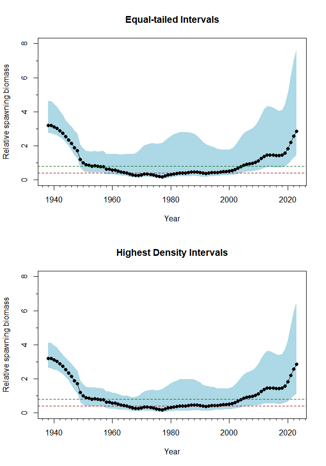

## Pacific Cod

Using results for Area 3CD from Fisheries and Ocean Canada’s [Status update of Pacific Cod (*Gadus Macrocephalus*) off the west coast of Vancouver Island in 2023](https://publications.gc.ca/collections/collection_2024/mpo-dfo/fs70-7/Fs70-7-2024-003-eng.pdf), with MCMC results provided by Robyn Forrest. A Bayesian delay-difference model was fit to survey indices, commercial catch-per-unit-effort indices, commercial catch data, and a commercial mean weight index. Results from seven models (with slightly different parameter settings) were combined, with each model contributing 1,000 MCMC samples to the resulting model-averaged posteriors, yielding 7,000 MCMC samples for providing advice to managers.

### Recruitment

To create ETIs and HDIs for estimates for each year:

```r
credibility_cod <- 0.95
res_all_years_cod_rec <- create_intervals(cod_rec_mcmc,
                                          credibility = credibility_cod)
```

Full time series of recruitments using both types of intervals:

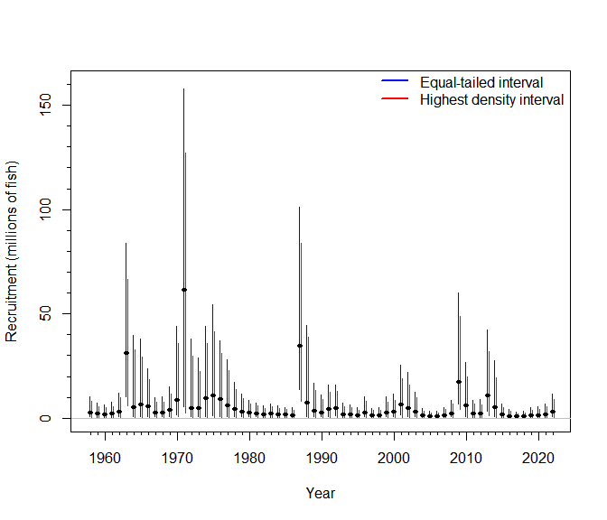

```r
plot(res_all_years_cod_rec,
     xlab = "Year",
     ylab = "Recruitment (millions of fish)",
     ylim = c(0, 160),
     y_tick_by = 10,
     add_line = 0,
     add_line_col = "grey",
     add_line_lty = 1)
```

Some pulling down of HDIs compared to ETIs, particularly 2009, 2013, 2022 and earlier years. To see the density plot for each year (not run here):

```r
plot(res_all_years_cod_rec,
     type = "hdi",
     xlim = c(0, 120),
     xlab = "Recruitment (millions of fish)",
     mfrow = c(33, 2))  # 65 default
```

The sum of the differences over all years between the width of the ETI and width of the HDI is (in millions of fish)

```r
res_all_years_cod_rec$intervals_all %>%
  dplyr::pull(width_diff) %>%
  sum()
```

```
#> [1] 238.4581
```

so smaller than for hake, as expected due to the smaller stock size.

### Spawning biomass relative to reference points

The upper stock reference point is the mean of the biomass estimates from 1956–2004, and the lower reference point is the lowest estimated biomass agreed upon as an undesirable state to be avoided, defined as the estimated biomass in 1986 for this stock. The biomass needs to be scaled by each reference point for every MCMC sample. Due to the different scales of the reference points, the calculations and resulting plots need to be done separately.

Relative to the upper stock reference point, above which the stock is considered to be healthy, the intervals of relative biomass for all years are calculated with:

```r
res_all_years_rel_usr <- create_intervals(cod_biomass_over_usr,
                                          credibility = credibility_cod)
```

[output not shown]

(The Warnings are due to not being able to compute lower end of interval a).

Plot the full time series like in our manuscript figure:

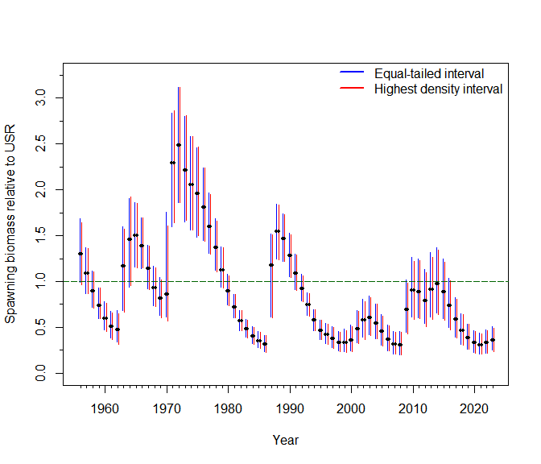

```r
plot(res_all_years_rel_usr,
     xlab = "Year",
     ylab = "Spawning biomass relative to USR",
     ylim = c(0, 3.25),
     y_tick_by = 0.25,
     add_line = 1,
     add_line_col = "darkgreen")
```

So there are only relatively minor changes, with only one year for which the interval overlapping or not overlapping the critical value of 1 changes with the definition of interval:

```r
dplyr::filter(res_all_years_rel_usr$intervals_all,
              eti_lower > 1,
              hdi_lower < 1)
```

```
#> # A tibble: 0 × 25
#> # ℹ 25 variables: quantity <dbl>, median <dbl>, eti_lower <dbl>,
#> #   eti_upper <dbl>, hdi_lower <dbl>, hdi_upper <dbl>, width_eti <dbl>,
#> #   width_hdi <dbl>, width_diff <dbl>, a_lower <dbl>, b_lower <dbl>,
#> #   i_eti_lower <int>, y_eti_lower <dbl>, i_eti_upper <int>, y_eti_upper <dbl>,
#> #   i_hdi_lower <int>, y_hdi_lower <dbl>, i_hdi_upper <int>, y_hdi_upper <dbl>,
#> #   hdi_height <lgl>, integral_full <dbl>, integral_eti <dbl>,
#> #   integral_hdi <dbl>, warning <lgl>, allow_hdi_zero <lgl>
```

```r
dplyr::filter(res_all_years_rel_usr$intervals_all,
              eti_upper > 1,
              hdi_upper < 1)
```

```
#> # A tibble: 1 × 25
#>   quantity median eti_lower eti_upper hdi_lower hdi_upper width_eti width_hdi
#>      <dbl>  <dbl>     <dbl>     <dbl>     <dbl>     <dbl>     <dbl>     <dbl>
#> 1     2009  0.689     0.450      1.01     0.426     0.982     0.564     0.556
#> # ℹ 17 more variables: width_diff <dbl>, a_lower <dbl>, b_lower <dbl>,
#> #   i_eti_lower <int>, y_eti_lower <dbl>, i_eti_upper <int>, y_eti_upper <dbl>,
#> #   i_hdi_lower <int>, y_hdi_lower <dbl>, i_hdi_upper <int>, y_hdi_upper <dbl>,
#> #   hdi_height <lgl>, integral_full <dbl>, integral_eti <dbl>,
#> #   integral_hdi <dbl>, warning <lgl>, allow_hdi_zero <lgl>
```

So in this case the perception of stock status does not really change when using HDIs instead of ETIs, presumably because the distributions look somewhat symmetric (at least the median is roughly in the middle of the intervals).

Relative to the lower reference point, below which the stock is considered to be in a critical zone, the intervals of relative biomass for all years are calculated here. The lower reference point for this stock is defined as the biomass in 1986 (the lowest estimated biomass agreed upon as an undesirable state to be avoided), and so this year is removed from the interval calculations because the relative biomass values would be 1 for each MCMC sample in 1986 (since the biomass would be scaled by itself, by definition the stock is at the reference point in 1986):

```r
res_all_years_rel_lrp <- create_intervals(dplyr::select(cod_biomass_over_lrp,
                                                        -"1986"),
                                          credibility = credibility_cod)
```

```
#> Warning in min(which(dens$y > y_eti_upper & dens$x < intervals$eti_lower)): no
#> non-missing arguments to min; returning Inf
#> Warning in min(which(dens$y > y_eti_upper & dens$x < intervals$eti_lower)): no
#> non-missing arguments to min; returning Inf
```

(Warnings are same as earlier.)

Plot the full time series like in our manuscript figure:

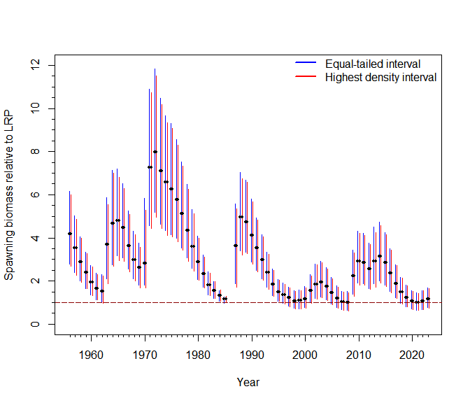

Again, the intervals do not change greatly between the ETIs and HDIs due to apparent symmetry.

## Absolute spawning biomass

Given the symmetry noted above for relative biomass, it is slightly surprising that the intervals do change somewhat when looking at absolute spawning biomass:

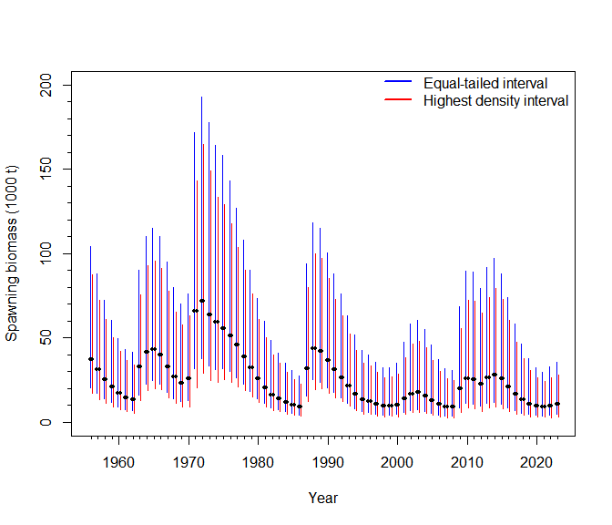

```r
res_all_years_cod_biomass <- create_intervals(cod_biomass_mcmc,
                                              credibility = credibility_cod)
plot(res_all_years_cod_biomass,
     xlab = "Year",
     ylab = "Spawning biomass (1000 t)",
     ylim = c(0, 200),
     y_tick_by = 10)
```